# Module 8 - Basics of Regression

Module 8 will cover the basics of regression, along with the concepts of estimating a model’s quality and distinguishing between correlation and causation.

## M8L1 - Introduction to Regression

*Lecture 1 - Introduction to Regression (5:12)*

### Regression

Regression is one of the most common models in analytics. Regression can answer two types of questions.

- How do systems work? Examples:
  - Value of a home run
  - Effect of economic factors on presidential election
  - Impact of education on income
  - Key factors in car purchasing
- What will happen in the future? Examples:
  - Height of a child at adulthood
  - Oil price 1.5 years from now
  - Housing demand in next 6 months
  - Remaining lifetime of insurance applicant

### Simple Linear Regression (SLR)

- Linear regression with one predictor
- Look for linear relationship between predictor and response

- $y$: Response (new car sales)
- $x_1$: Predictor (workforce participation)

Regression equation:

$$\begin{equation}
y = a_0 + a_1x_1
\label{eq:regression}
\end{equation}$$

Regression equation with $m$ predictors:
$$\begin{split}
y &= a_0 + a_1x_1 + a_2x_2 + \dots + + a_mx_m \\
&= a_0 + \sum_{j=1}^m a_jx_j
\end{split}$$

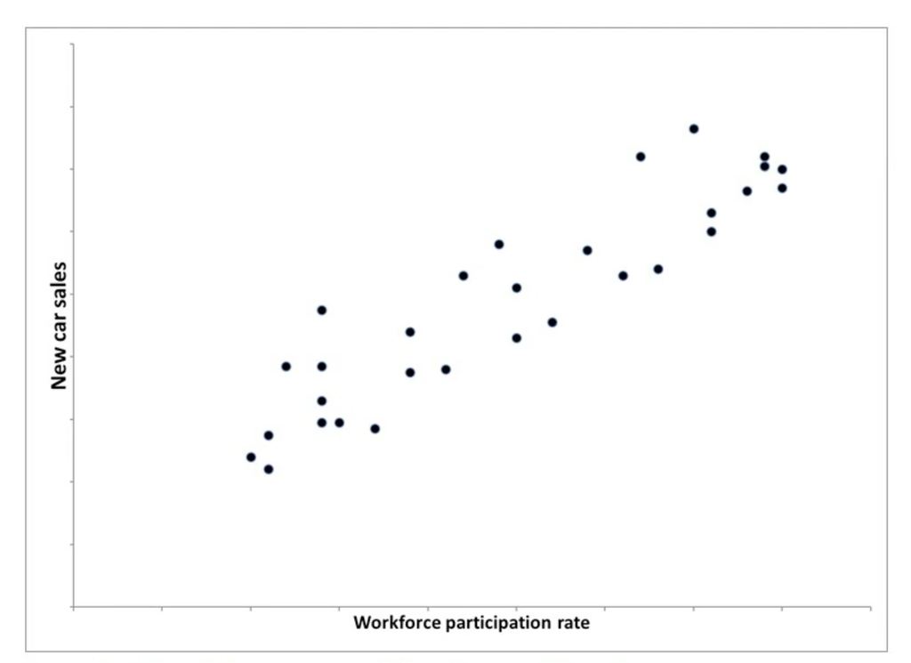

Linear regression with one predictor

Measure the quality of the line’s fit with squared errors.

- $y_i$: Cars sold for data point $i$
- $\hat{y}_i$: Model’s prediction of cars sold

Data point $i$ prediction error:
$$y_i - \hat{y}_i = y_i - (a_0 + a_1x_{i1})$$

Sum of squared errors:
$$\begin{split}
& \sum_{i=1}^n (y_i - \hat{y}_i)^2 \\
&= \sum_{i=1}^n (y_i - \big(a_0 + a_1x_{i1})\big)^2
\end{split}$$

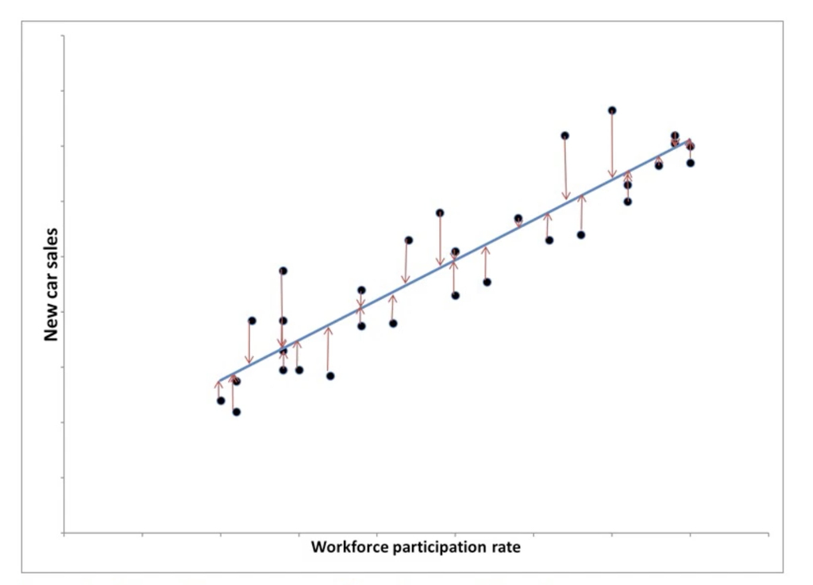

Linear regression prediction error

## M8L2 - Maximum Likelihood and Information Criteria

*Lecture 2 - Maximum Likelihood and Information Criteria (7:56)*

## M8L3 - Using Regression

*Lecture 3 - Using Regression (3:33)*

## M8L4 - Causation vs. Correlation

*Lecture 4 - Causation vs. Correlation (6:10)*

## M8L5 - Transformations and Interactions

*Lecture 5 - Transformations and Interactions (2:17)*

## M8L6 - Output

*Lecture 6 - Output (5:05)*